# Lab 3

Author

Scott Brydon

#### Declaring Libraries and Loading Data

```r
library(tidyverse)
library(here)
hiphop <- read_csv(here("data", "hiphop.csv"))
```

#### Summary of Data

1. This study was conducted at the University of Minnesota, where 168 students enrolled in undergraduate linguistics, sociology, and music classes where asked to report their familiarity with 64 separate African-American English words. A coding scheme was established for allow the participants to rate their familiarity of each word on a five-point Likert scale (1 = not at all, 5 = well). In total, the hip-hop data contains 10,752 rows and 38 columns. The 38 columns are comprised of demographic, social network, music, pop-culture, and experimental times variables.
2. Each row represents one of the 64 familiarity ratings (1 - 5) given by each of the 168 participants throughout the study. Hence why we have 10,752 rows (168 * 64).
3. Missing values were replaced with mean values for some of our variables. A major benefit would be that summarizing columns of data with NA values can cause complications, and by turning those NAs into mean values we fix that issue. A drawback would be that we’re making a risky assumption that those participants’ responses would align with the mean value of that variable, which could skew our data.

#### 4. Cleaning Data

```r
#drop_na() takes away way too many observations in my opinion
hiphop_clean <- hiphop |>
  mutate(
    across(c(word, subj, sex, ethnic), as.factor)
    )
```

#### 5. Unique AAE Words

```r
distinct(hiphop_clean, word) |>
  count()
```

```
# A tibble: 1 × 1
      n
  <int>
1    64
```

#### 6. Re-categorize Ethnic

```r
new_hiphop_clean <- hiphop_clean |>
  mutate(
    white_or_nonwhite =
      if_else(ethnic != "white", "non-white", "white"),
    white_or_nonwhite =
      as.factor(white_or_nonwhite)
  )
```

#### 7. Demographics

```r
demographics <- new_hiphop_clean |>
  distinct(subj, .keep_all = TRUE) |>
  select(sex, age, white_or_nonwhite) |>
  summary()
```

#### 8. Graphs of Demographics

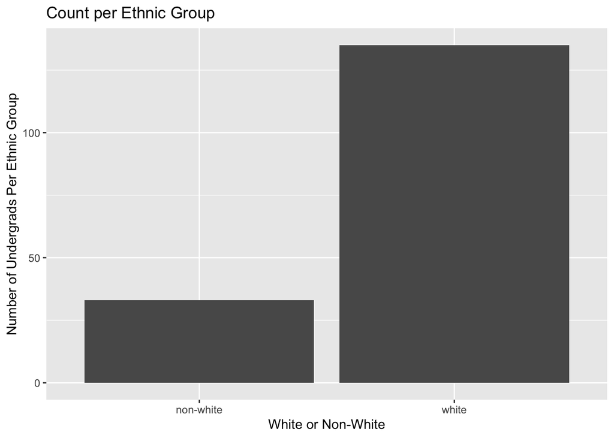

```r
new_hiphop_graphable <- new_hiphop_clean |>
  distinct(subj, .keep_all = TRUE)

new_hiphop_graphable |>
  ggplot(mapping = aes(x = white_or_nonwhite)) +
  geom_bar() +
  labs(title = "Count per Ethnic Group",
       x = "White or Non-White",
       y = "Number of Undergrads Per Ethnic Group")
```

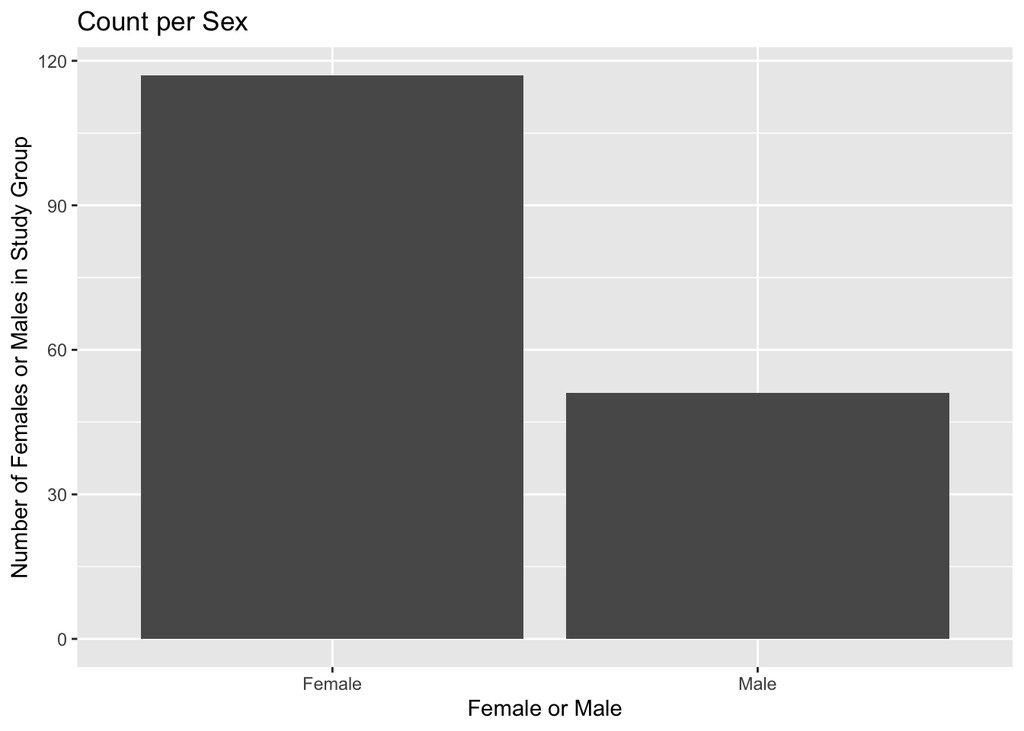

```r
new_hiphop_graphable |>
  ggplot(mapping = aes(x = sex)) +
  geom_bar() +
  labs(title = "Count per Sex", x = "Female or Male",
       y = "Number of Females or Males in Study Group")
```

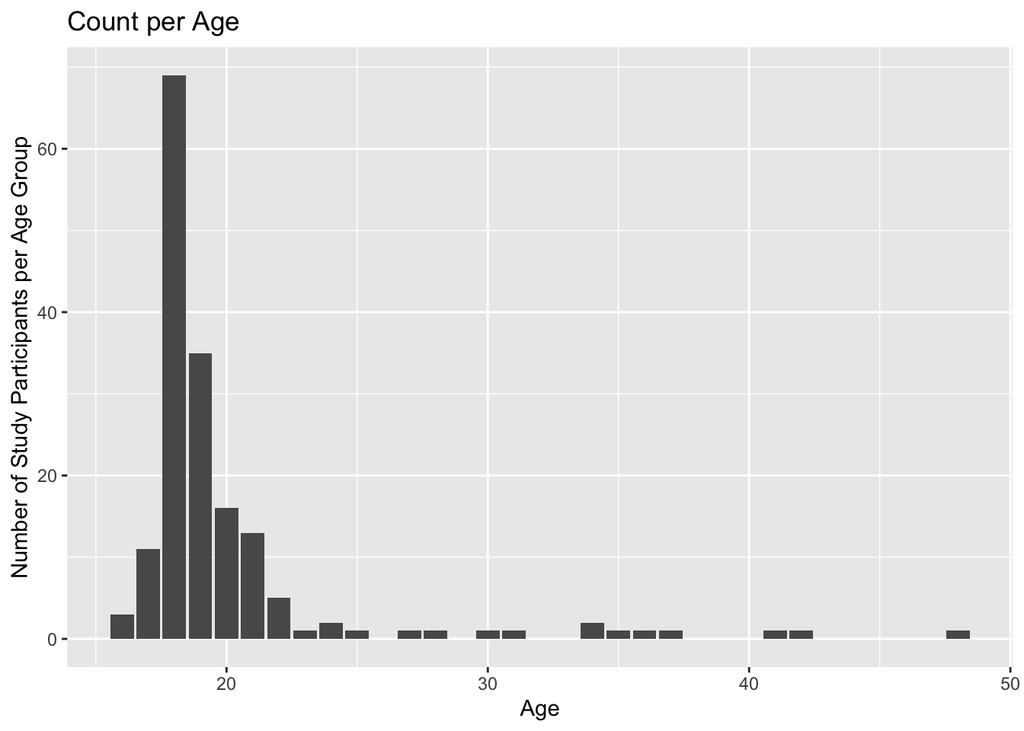

```r
new_hiphop_graphable |>
  ggplot(mapping = aes(x = age)) +
  geom_bar() +
  labs(title = "Count per Age",
       x = "Age",
       y = "Number of Study Participants per Age Group")
```

#### Familiar Words

```r
#a. People below the age of 20
new_hiphop_clean |>
  filter(age < 20) |>
  group_by(word) |>
  summarize(mean = mean(familiarity)) |>
  slice(c(which.min(mean), which.max(mean)))
```

```
# A tibble: 2 × 2
  word              mean
  <fct>            <dbl>
1 catch the vapors  1.03
2 off the hook      4.42
```

```r
#b. Non-white women
new_hiphop_clean |>
  filter(sex == "Female" & white_or_nonwhite == "non-white") |>
  group_by(word) |>
  summarize(mean = mean(familiarity)) |>
  slice(c(which.min(mean), which.max(mean)))
```

```
# A tibble: 2 × 2
  word               mean
  <fct>             <dbl>
1 break someone out  1
2 feel me            4.19
```

```r
#c. White men above age of 30
new_hiphop_clean |>
  filter(sex == "Male" & white_or_nonwhite == "white" & age > 30) |>
  group_by(word) |>
  summarize(mean = mean(familiarity)) |>
  slice(c(which.min(mean), which.max(mean)))
```

```
# A tibble: 2 × 2
  word        mean
  <fct>      <dbl>
1 ay yo trip   1
2 5-0          4.2
```

A. For people below the age of 20, the least familiar word was “catch the vapors”, while the most familiar was “off the hook.

B. For non-white women, the 4 words tied for least familiar were “break someone out”. The most familiar word was “feel me”

C. For white men above the age of 30, there were lots of unfamiliar words, but “ay yo trip” was the most unfamiliar. The most familiar words on average was “5-0”.

#### Study Subjects

```r
new_hiphop_clean |>
  distinct(subj, .keep_all = TRUE) |>
  filter(
      (white_or_nonwhite == "white"),
      (age >= 17 & age <= 23),
      (city >= 10000 & city <= 60000),
      (sex == "Male"),
      (bieber >= 5)
           ) |>
  pull(subj)
```

```
[1] p17
168 Levels: p1 p10 p101 p102 p103 p105 p106 p107 p108 p109 p11 p110 ... p99
```

Even though I believe subject p17 is Justin Bieber, it’s weird his rating for the “Bieber” familiarity question wasn’t 6. Whenever I filtered by Bieber == 6, there were no male subjects.